# Programming Assignment 1: Numerical Optimization for Logistic Regression

### Name: Danfeng Sun[20037470]

This notebook implements `\ell_2`-regularized logistic regression and four numerical optimization algorithms to solve it: **Gradient Descent (GD)**, **Stochastic Gradient Descent (SGD)**, and **Mini-Batch SGD (MB-SGD)** with batch sizes $b=8$ and $b=64$.

## 0. Tasks

1. Read the lecture note `logistic.pdf`.
2. Read, complete, and run the code.
3. **Implement mini-batch SGD** and evaluate the performance.
4. Convert the `.ipynb` file to an `.html` file containing the code **and** the execution output.

**Grading criteria**

1. When computing the gradient and objective value over a batch, use **matrix-vector multiplication** rather than a FOR LOOP of vector-vector multiplications.
2. Plot the objective function value against epochs, comparing GD, SGD, and MB-SGD ($b=8$ and $b=64$). All four curves must converge to the same value.

# 1. Data processing

- The **Diabetes** dataset (`n = 768` samples, `d = 8` features, labels in $\{-1, +1\}$) is from https://www.csie.ntu.edu.tw/~cjlin/libsvmtools/datasets/binary/diabetes
- Load it with scikit-learn, then preprocess.

```python
import numpy

# Fix the random seed so the results and plots are reproducible.
numpy.random.seed(42)
```

## 1.1. Load the data

```python
from sklearn import datasets

# The file 'diabetes' is in LIBSVM sparse format.
x_sparse, y = datasets.load_svmlight_file('diabetes')
x = numpy.asarray(x_sparse.todense())  # dense n-by-d array

print('Shape of x: ' + str(x.shape))
print('Shape of y: ' + str(y.shape))
print('Labels in y: ' + str(numpy.unique(y)))
```

```
Shape of x: (768, 8)
Shape of y: (768,)
Labels in y: [-1.  1.]
```

## 1.2. Partition to training and test sets

```python
# partition the data to training and test sets
n = x.shape[0]
n_train = 640
n_test = n - n_train

rand_indices = numpy.random.permutation(n)
train_indices = rand_indices[0:n_train]
test_indices = rand_indices[n_train:n]

x_train = x[train_indices, :]
x_test = x[test_indices, :]
y_train = y[train_indices].reshape(n_train, 1)
y_test = y[test_indices].reshape(n_test, 1)

print('Shape of x_train: ' + str(x_train.shape))
print('Shape of x_test: ' + str(x_test.shape))
print('Shape of y_train: ' + str(y_train.shape))
print('Shape of y_test: ' + str(y_test.shape))
```

```
Shape of x_train: (640, 8)
Shape of x_test: (128, 8)
Shape of y_train: (640, 1)
Shape of y_test: (128, 1)
```

## 1.3. Feature scaling

Use standardization to transform both the training and test features. The mean `mu` and standard deviation `sig` are computed on the **training set only** and then applied to both sets.

```python
# Standardization

# calculate mu and sig using the training set
d = x_train.shape[1]
mu = numpy.mean(x_train, axis=0).reshape(1, d)
sig = numpy.std(x_train, axis=0).reshape(1, d)

# transform the training features
x_train = (x_train - mu) / (sig + 1E-6)

# transform the test features
x_test = (x_test - mu) / (sig + 1E-6)

print('test mean = ')
print(numpy.mean(x_test, axis=0))

print('test std = ')
print(numpy.std(x_test, axis=0))
```

```
test mean =
[-0.04167763  0.06382918  0.04651846  0.0346151  -0.0802037   0.05449143
  0.10215887 -0.03404356]
test std =
[0.91871006 1.05397137 0.83376488 0.95078193 0.92855798 0.86902242
 1.0876592  0.97744259]
```

## 1.4. Add a dimension of all ones

Appending a constant `1` feature lets the bias (intercept) term be absorbed into the weight vector `w`.

```python
n_train, d = x_train.shape
x_train = numpy.concatenate((x_train, numpy.ones((n_train, 1))), axis=1)

n_test, d = x_test.shape
x_test = numpy.concatenate((x_test, numpy.ones((n_test, 1))), axis=1)

print('Shape of x_train: ' + str(x_train.shape))
print('Shape of x_test: ' + str(x_test.shape))
```

```
Shape of x_train: (640, 9)
Shape of x_test: (128, 9)
```

# 2. Logistic regression model

The objective function is $$Q (w; X, y) = \frac{1}{n} \sum_{i=1}^n \log \Big( 1 + \exp \big( - y_i x_i^T w \big) \Big) + \frac{\lambda}{2} \| w \|_2^2 .$$

```python
# Calculate the objective function value
# Inputs:
#     w: d-by-1 matrix
#     x: n-by-d matrix
#     y: n-by-1 matrix
#     lam: scalar, the regularization parameter
# Return:
#     objective function value (scalar)
def objective(w, x, y, lam):
    n, d = x.shape
    yx = numpy.multiply(y, x)        # n-by-d matrix
    yxw = numpy.dot(yx, w)           # n-by-1 matrix
    vec1 = numpy.exp(-yxw)           # n-by-1 matrix
    vec2 = numpy.log(1 + vec1)       # n-by-1 matrix
    loss = numpy.mean(vec2)          # scalar
    reg = lam / 2 * numpy.sum(w * w) # scalar
    return loss + reg
```

```python
# initialize w
d = x_train.shape[1]
w = numpy.zeros((d, 1))

# evaluate the objective function value at w
lam = 1E-6
objval0 = objective(w, x_train, y_train, lam)
print('Initial objective function value = ' + str(objval0))
```

```
Initial objective function value = 0.6931471805599453
```

# 3. Numerical optimization

## 3.1. Gradient descent

The full gradient at $w$ is $$g = \nabla Q(w) = - \frac{1}{n} \sum_{i=1}^n \frac{y_i x_i}{1 + \exp(y_i x_i^T w)} + \lambda w.$$

```python
# Calculate the gradient
# Inputs:
#     w: d-by-1 matrix
#     x: n-by-d matrix
#     y: n-by-1 matrix
#     lam: scalar, the regularization parameter
# Return:
#     g: d-by-1 matrix, full gradient
def gradient(w, x, y, lam):
    n, d = x.shape
    yx = numpy.multiply(y, x)                          # n-by-d matrix
    yxw = numpy.dot(yx, w)                             # n-by-1 matrix
    vec1 = numpy.exp(yxw)                              # n-by-1 matrix
    vec2 = numpy.divide(yx, 1 + vec1)                  # n-by-d matrix
    vec3 = -numpy.mean(vec2, axis=0).reshape(d, 1)     # d-by-1 matrix
    g = vec3 + lam * w
    return g
```

```python
# Gradient descent for solving logistic regression
# Inputs:
#     x: n-by-d matrix
#     y: n-by-1 matrix
#     lam: scalar, the regularization parameter
#     stepsize: scalar
#     max_iter: integer, the maximal iterations
#     w: d-by-1 matrix, initialization of w
# Return:
#     w: d-by-1 matrix, the solution
#     objvals: a record of each iteration's objective value
def grad_descent(x, y, lam, stepsize, max_iter=100, w=None):
    n, d = x.shape
    objvals = numpy.zeros(max_iter)   # store the objective values
    if w is None:
        w = numpy.zeros((d, 1))       # zero initialization

    for t in range(max_iter):
        objval = objective(w, x, y, lam)
        objvals[t] = objval
        g = gradient(w, x, y, lam)
        w = w - stepsize * g

    print('Final objective value of GD: ' + str(objvals[-1]))
    return w, objvals
```

Run gradient descent. For GD, one iteration is one epoch, so `max_iter = 100` means 100 epochs.

```python
lam = 1E-6
stepsize = 1.0
w, objvals_gd = grad_descent(x_train, y_train, lam, stepsize)
```

```
Final objective value of GD: 0.469821346946509
```

## 3.2. Stochastic gradient descent (SGD)

Define $Q_i (w) = \log \Big( 1 + \exp \big( - y_i x_i^T w \big) \Big) + \frac{\lambda}{2} \| w \|_2^2 $.

The stochastic gradient at $w$ is $g_i = \frac{\partial Q_i}{\partial w} = -\frac{y_i x_i}{1 + \exp(y_i x_i^T w)} + \lambda w.$

```python
# Calculate the objective Q_i and the gradient of Q_i
# Inputs:
#     w: d-by-1 matrix
#     xi: 1-by-d matrix
#     yi: scalar
#     lam: scalar, the regularization parameter
# Return:
#     obj: scalar, the objective Q_i
#     g: d-by-1 matrix, gradient of Q_i
def stochastic_objective_gradient(w, xi, yi, lam):
    xi = numpy.asarray(xi).reshape(1, -1)   # ensure xi is a 1-by-d row
    yx = yi * xi                            # 1-by-d matrix
    yxw = float(numpy.dot(yx, w).item())    # scalar

    # calculate objective function Q_i
    loss = numpy.log(1 + numpy.exp(-yxw))   # scalar
    reg = lam / 2 * numpy.sum(w * w)        # scalar
    obj = loss + reg

    # calculate stochastic gradient
    g_loss = -yx.T / (1 + numpy.exp(yxw))   # d-by-1 matrix
    g = g_loss + lam * w                    # d-by-1 matrix

    return obj, g
```

```python
# SGD for solving logistic regression
# Inputs:
#     x: n-by-d matrix
#     y: n-by-1 matrix
#     lam: scalar, the regularization parameter
#     stepsize: scalar
#     max_epoch: integer, the maximal epochs
#     w: d-by-1 matrix, initialization of w
# Return:
#     w: the solution
#     objvals: record of each epoch's average objective value
def sgd(x, y, lam, stepsize, max_epoch=100, w=None):
    n, d = x.shape
    objvals = numpy.zeros(max_epoch)   # store the objective values
    if w is None:
        w = numpy.zeros((d, 1))        # zero initialization

    for t in range(max_epoch):
        # randomly shuffle the samples
        rand_indices = numpy.random.permutation(n)
        x_rand = x[rand_indices, :]
        y_rand = y[rand_indices, :]

        objval = 0   # accumulate the objective values
        for i in range(n):
            xi = x_rand[i, :]          # 1-by-d matrix
            yi = float(y_rand[i, 0])   # scalar
            obj, g = stochastic_objective_gradient(w, xi, yi, lam)
            objval += obj
            w = w - stepsize * g

        stepsize *= 0.9   # decrease step size to guarantee convergence
        objval /= n
        objvals[t] = objval

    print('Final objective value of SGD: ' + str(objvals[-1]))
    return w, objvals
```

Run SGD. For SGD, one epoch visits all $n$ samples once (i.e., $n$ iterations).

```python
lam = 1E-6
stepsize = 0.1
w, objvals_sgd = sgd(x_train, y_train, lam, stepsize)
```

```
Final objective value of SGD: 0.46982414943588874
```

# 4. Compare GD with SGD

Plot objective function values against epochs.

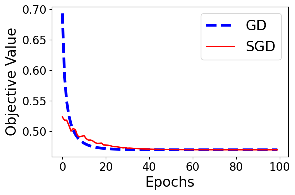

```python
import matplotlib.pyplot as plt
%matplotlib inline

fig = plt.figure(figsize=(6, 4))

epochs_gd = range(len(objvals_gd))
epochs_sgd = range(len(objvals_sgd))

line0, = plt.plot(epochs_gd, objvals_gd, '--b', linewidth=4)
line1, = plt.plot(epochs_sgd, objvals_sgd, '-r', linewidth=2)
plt.xlabel('Epochs', fontsize=20)
plt.ylabel('Objective Value', fontsize=20)
plt.xticks(fontsize=16)
plt.yticks(fontsize=16)
plt.legend([line0, line1], ['GD', 'SGD'], fontsize=20)
plt.tight_layout()
plt.show()
```

# 5. Prediction

Use the trained `w` (the SGD solution above) to make predictions via $f(x') = \mathrm{sgn}(w^T x')$, and evaluate the classification error on the training and test sets.

```python
# Predict class label
# Inputs:
#     w: d-by-1 matrix
#     X: m-by-d matrix
# Return:
#     f: m-by-1 matrix, the predictions
def predict(w, X):
    xw = numpy.dot(X, w)
    f = numpy.sign(xw)
    return f
```

```python
# evaluate training error
f_train = predict(w, x_train)
diff = numpy.abs(f_train - y_train) / 2
error_train = numpy.mean(diff)
print('Training classification error is ' + str(error_train))
```

```
Training classification error is 0.2140625
```

```python
# evaluate test error
f_test = predict(w, x_test)
diff = numpy.abs(f_test - y_test) / 2
error_test = numpy.mean(diff)
print('Test classification error is ' + str(error_test))
```

```
Test classification error is 0.2421875
```

# 6. Mini-batch SGD (the implementation task)

## 6.1. Compute the objective $Q_I$ and its gradient using a batch of samples

Define $$Q_I (w) = \frac{1}{b} \sum_{i \in I} \log \Big( 1 + \exp \big( - y_i x_i^T w \big) \Big) + \frac{\lambda}{2} \| w \|_2^2 ,$$ where $I$ is a set of $b$ indices drawn from $\{1, \cdots, n\}$ without replacement.

The mini-batch gradient at $w$ is $$g_I = \frac{\partial Q_I}{\partial w} = \frac{1}{b} \sum_{i \in I} \frac{- y_i x_i}{1 + \exp(y_i x_i^T w)} + \lambda w.$$

Everything below is computed with **matrix-vector multiplication** over the whole batch at once (no inner FOR loop over the $b$ samples).

```python
# Calculate the objective Q_I and the gradient of Q_I
# Inputs:
#     w:   d-by-1 matrix
#     xi:  b-by-d matrix (a batch of b feature vectors)
#     yi:  b-by-1 matrix (the corresponding labels)
#     lam: scalar, the regularization parameter
#     b:   integer, the batch size
# Return:
#     obj: scalar, the objective Q_I
#     g:   d-by-1 matrix, gradient of Q_I
def mb_stochastic_objective_gradient(w, xi, yi, lam, b):
    # yx[i, :] = yi * xi  (broadcast the label across each feature row)
    yx = numpy.multiply(yi, xi)            # b-by-d matrix
    yxw = numpy.dot(yx, w)                 # b-by-1 matrix  (matrix-vector product)

    # calculate the objective function Q_I (averaged over the batch)
    loss = numpy.mean(numpy.log(1 + numpy.exp(-yxw)))   # scalar
    reg = lam / 2 * numpy.sum(w * w)                    # scalar
    obj = loss + reg

    # calculate the mini-batch gradient (averaged over the batch)
    d = w.shape[0]
    vec = numpy.divide(yx, 1 + numpy.exp(yxw))          # b-by-d matrix
    g_loss = -numpy.mean(vec, axis=0).reshape(d, 1)     # d-by-1 matrix
    g = g_loss + lam * w                                # d-by-1 matrix

    return obj, g
```

## 6.2. Implement mini-batch SGD

Following the SGD implementation:

1. In every epoch, randomly permute the $n$ samples.
2. Each epoch has $\frac{n}{b}$ iterations; each iteration uses the next $b$ samples to compute the objective and gradient via `mb_stochastic_objective_gradient`.
3. Record **one** objective value per epoch (the mean of the batch objectives).
4. Decrease the step size after every epoch (as in SGD).

```python
# Mini-Batch SGD for solving logistic regression
# Inputs:
#     x: n-by-d matrix
#     y: n-by-1 matrix
#     lam: scalar, the regularization parameter
#     b: integer, the batch size
#     stepsize: scalar
#     max_epoch: integer, the maximal epochs
#     w: d-by-1 matrix, initialization of w
# Return:
#     w: the solution
#     objvals: record of each epoch's average objective value
def mb_sgd(x, y, lam, b, stepsize, max_epoch=100, w=None):
    n, d = x.shape
    objvals = numpy.zeros(max_epoch)    # store one objective value per epoch
    if w is None:
        w = numpy.zeros((d, 1))         # zero initialization

    num_batch = int(numpy.floor(n / b)) # number of iterations per epoch

    for t in range(max_epoch):
        # randomly shuffle the samples (just like SGD)
        rand_indices = numpy.random.permutation(n)
        x_rand = x[rand_indices, :]
        y_rand = y[rand_indices, :]

        objval = 0   # accumulate the per-batch objective values
        for j in range(num_batch):
            # take the j-th batch of b samples
            xi = x_rand[j*b : (j+1)*b, :]   # b-by-d matrix
            yi = y_rand[j*b : (j+1)*b, :]   # b-by-1 matrix
            obj, g = mb_stochastic_objective_gradient(w, xi, yi, lam, b)
            objval += obj
            w = w - stepsize * g

        stepsize *= 0.9          # decrease step size to guarantee convergence
        objval /= num_batch      # average objective over the batches in this epoch
        objvals[t] = objval

    print('Final objective value of MB-SGD (b=' + str(b) + '): ' + str(objvals[-1]))
    return w, objvals
```

## 6.3. Run MB-SGD

A larger batch produces a less noisy gradient, so it can tolerate (and benefits from) a larger step size. For $b=8$ a step size of `0.1` works well; for $b=64$ a larger initial step size of `1.0` lets it reach the same minimum within 100 epochs.

```python
# MB-SGD with batch size b=8
lam = 1E-6   # do not change
b = 8        # do not change
stepsize = 0.1   # tuned

w_mb8, objvals_mbsgd8 = mb_sgd(x_train, y_train, lam, b, stepsize)
```

```
Final objective value of MB-SGD (b=8): 0.4698219303559418
```

```python
# MB-SGD with batch size b=64
lam = 1E-6   # do not change
b = 64       # do not change
stepsize = 1.0   # tuned

w_mb64, objvals_mbsgd64 = mb_sgd(x_train, y_train, lam, b, stepsize)
```

```
Final objective value of MB-SGD (b=64): 0.4698220671224835
```

## 6.4. Evaluate the performance of the MB-SGD solution

Use the MB-SGD ($b=8$) solution `w_mb8` to evaluate the training and test classification accuracy.

```python
f_train = predict(w_mb8, x_train)
acc_train = 1 - numpy.mean(numpy.abs(f_train - y_train) / 2)

f_test = predict(w_mb8, x_test)
acc_test = 1 - numpy.mean(numpy.abs(f_test - y_test) / 2)

print('MB-SGD (b=8) training accuracy: ' + str(float(acc_train)))
print('MB-SGD (b=8) test accuracy:     ' + str(float(acc_test)))
```

```
MB-SGD (b=8) training accuracy: 0.7859375
MB-SGD (b=8) test accuracy:     0.7578125
```

# 7. Plot and compare GD, SGD, and MB-SGD

Four curves of objective value vs. epochs: GD, SGD, MB-SGD ($b=8$), MB-SGD ($b=64$).

Logistic regression with $\ell_2$-norm regularization is a **strongly convex** problem, so all algorithms converge to the **same** unique minimum. The final objective values of all four curves should coincide.

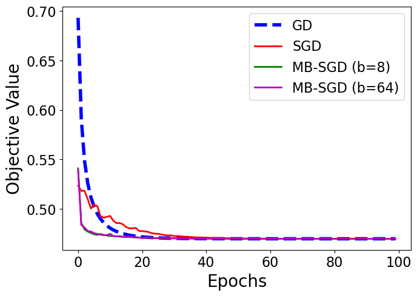

```python
fig = plt.figure(figsize=(7, 5))

epochs_gd = range(len(objvals_gd))
epochs_sgd = range(len(objvals_sgd))
epochs_mb8 = range(len(objvals_mbsgd8))
epochs_mb64 = range(len(objvals_mbsgd64))

line0, = plt.plot(epochs_gd, objvals_gd, '--b', linewidth=4)
line1, = plt.plot(epochs_sgd, objvals_sgd, '-r', linewidth=2)
line2, = plt.plot(epochs_mb8, objvals_mbsgd8, '-g', linewidth=2)
line3, = plt.plot(epochs_mb64, objvals_mbsgd64, '-m', linewidth=2)

plt.xlabel('Epochs', fontsize=20)
plt.ylabel('Objective Value', fontsize=20)
plt.xticks(fontsize=16)
plt.yticks(fontsize=16)
plt.legend([line0, line1, line2, line3],
           ['GD', 'SGD', 'MB-SGD (b=8)', 'MB-SGD (b=64)'], fontsize=16)
plt.tight_layout()
plt.show()
```

```python
# Confirm all four algorithms converged to (essentially) the same objective value
print('Final objective values:')
print('  GD            = {:.6f}'.format(objvals_gd[-1]))
print('  SGD           = {:.6f}'.format(objvals_sgd[-1]))
print('  MB-SGD (b=8)  = {:.6f}'.format(objvals_mbsgd8[-1]))
print('  MB-SGD (b=64) = {:.6f}'.format(objvals_mbsgd64[-1]))
```

```
Final objective values:
  GD            = 0.469821
  SGD           = 0.469824
  MB-SGD (b=8)  = 0.469822
  MB-SGD (b=64) = 0.469822
```

# 8. Summary